# Meta-análises

Clarissa F. D. Carneiro

2022-10-18

[output not shown]

Depois da limpeza, importamos dados de volta para análises.

Para análises, precisamos da média e n dos dois grupos e da variacao no tratado, seja SEM, SD ou Unclear. Excluímos todos os casos em que falta pelo menos um desses valores.

Para montar um fluxograma: Número de comparações extraídas = 1652 Número de comparações excluídas por falta de dados = 453

Outras limpezas:

Como re-extraímos alguns valores durante a verificacao de outliers, precisamos usar esses valores corrigidos

Calculei SDs a partir de SEMs (se estava ‘unclear’, considerei SEM).

Para usar SMD, precisamos do SD dos dois grupos necessariamente - decidimos considerar sd do controle igual ao tratado (que vai ser igual ao pooled).

# 2-level

Meta-análise (2-level SMD)

```
##
## Random-Effects Model (k = 1199; tau^2 estimator: REML)
##
##     logLik    deviance         AIC         BIC        AICc
## -3729.4212   7458.8424   7462.8424   7473.0192   7462.8524
##
## tau^2 (estimated amount of total heterogeneity): 12.2884 (SE = 0.6310)
## tau (square root of estimated tau^2 value):      3.5055
## I^2 (total heterogeneity / total variability):   91.86%
## H^2 (total variability / sampling variability):  12.29
##
## Test for Heterogeneity:
## Q(df = 1198) = 7182.0443, p-val < .0001
##
## Model Results:
##
## estimate      se      zval    pval    ci.lb    ci.ub
##  -4.6388  0.1159  -40.0219  <.0001  -4.8660  -4.4116  ***
##
## ---
## Signif. codes:  0 '***' 0.001 '**' 0.01 '*' 0.05 '.' 0.1 ' ' 1
```

```
##
##        estimate   ci.lb   ci.ub
## tau^2   12.2884 23.4240 31.0726
## tau      3.5055  4.8398  5.5743
## I^2(%)  91.8632 95.5596 96.6156
## H^2     12.2899 22.5205 29.5476
```

OBS: aqui tem mais uma exclusao de uma comparacao por causa de n=1

[output not shown]

# 3-level

Meta-análise (3-level SMD)

```
##
## Multivariate Meta-Analysis Model (k = 1199; method: REML)
##
## Variance Components:
##
##             estim    sqrt  nlvls  fixed                    factor
## sigma^2.1  7.4350  2.7267    359     no                rayyan.key
## sigma^2.2  5.3878  2.3212   1199     no  rayyan.key/Comparison_ID
##
## Test for Heterogeneity:
## Q(df = 1198) = 7182.0443, p-val < .0001
##
## Model Results:
##
## estimate      se      zval    pval    ci.lb    ci.ub
##  -5.2780  0.1864  -28.3164  <.0001  -5.6434  -4.9127  ***
##
## ---
## Signif. codes:  0 '***' 0.001 '**' 0.01 '*' 0.05 '.' 0.1 ' ' 1
```

```
## $results
##               % of total variance    I2
## Level 1                  7.824227   ---
## Level 2 (exp)           38.729845 38.73
## Level 3 (art)           53.445928 53.45
##
## $totalI2
## [1] 92.17577
##
## $plot
```

```
##
## attr(,"class")
## [1] "mlm.variance.distribution" "list"
```

### excluindo n de replicatas ou outras unidades nao independentes

```
##
##                             n_definition   n
## 1                                 assays  20
## 2                  biological replicates   5
## 3                          cell cultures   2
## 4                         determinations   8
## 5                            experiments 107
## 6             independent determinations  13
## 7  independent experimental measurements   6
## 8                independent experiments 547
## 9                independent repetitions   2
## 10                independent replicates   2
## 11           independent sets of studies   1
## 12                          observations   1
## 13                            replicates 218
## 14                               samples  12
## 15                                 wells  24
## 16                                  <NA> 231
```

```
##
## Multivariate Meta-Analysis Model (k = 571; method: REML)
##
## Variance Components:
##
##             estim    sqrt  nlvls  fixed                    factor
## sigma^2.1  8.1900  2.8618    170     no                rayyan.key
## sigma^2.2  5.1667  2.2730    571     no  rayyan.key/Comparison_ID
##
## Test for Heterogeneity:
## Q(df = 570) = 3026.8419, p-val < .0001
##
## Model Results:
##
## estimate      se      zval    pval    ci.lb    ci.ub
##  -5.4876  0.2808  -19.5427  <.0001  -6.0380  -4.9372  ***
##
## ---
## Signif. codes:  0 '***' 0.001 '**' 0.01 '*' 0.05 '.' 0.1 ' ' 1
```

```
## $results
##               % of total variance    I2
## Level 1                  9.378013   ---
## Level 2 (exp)           35.054800 35.05
## Level 3 (art)           55.567187 55.57
##
## $totalI2
## [1] 90.62199
##
## $plot
```

```
##
## attr(,"class")
## [1] "mlm.variance.distribution" "list"
```

## Publication bias

Funnel plot

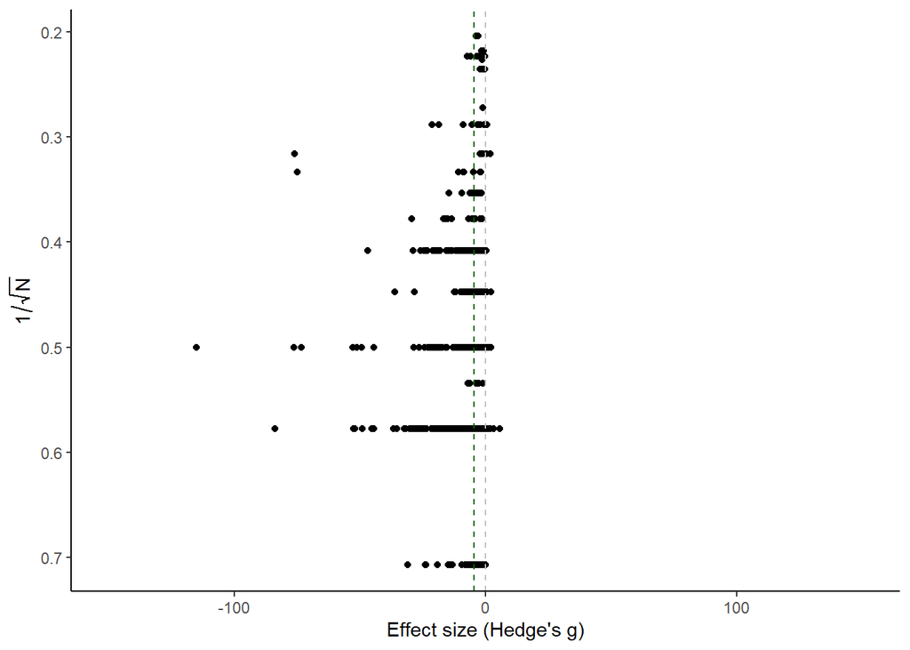

Egger’s regression

```
##
## Regression Test for Funnel Plot Asymmetry
##
## Model:     mixed-effects meta-regression model
## Predictor: inverse of the square root sample size
##
## Test for Funnel Plot Asymmetry: z = -2.4498, p = 0.0143
## Limit Estimate (as ni -> inf):  b = -3.1224 (CI: -4.3534, -1.8913)
```

# Meta-regressions (3-level)

Differentiation

```
##
## Multivariate Meta-Analysis Model (k = 1199; method: REML)
##
## Variance Components:
##
##             estim    sqrt  nlvls  fixed                    factor
## sigma^2.1  7.5328  2.7446    359     no                rayyan.key
## sigma^2.2  5.3688  2.3171   1199     no  rayyan.key/Comparison_ID
##
## Test for Residual Heterogeneity:
## QE(df = 1193) = 7112.4773, p-val < .0001
##
## Test of Moderators (coefficients 2:6):
## QM(df = 5) = 9.5094, p-val = 0.0904
##
## Model Results:
##
##                                                                                             estimate
## intrcpt                                                                                      -5.4078
## relevel(factor(dados_meta_smd$Diferentiation_method), ref = "No differentiation")ATRA         1.2629
## relevel(factor(dados_meta_smd$Diferentiation_method), ref = "No differentiation")ATRA plus   -0.5433
## relevel(factor(dados_meta_smd$Diferentiation_method), ref = "No differentiation")Other        0.0195
## relevel(factor(dados_meta_smd$Diferentiation_method), ref = "No differentiation")unclear      4.9547
## relevel(factor(dados_meta_smd$Diferentiation_method), ref = "No differentiation")Unclear     -1.0424
##                                                                                                 se
## intrcpt                                                                                     0.2054
## relevel(factor(dados_meta_smd$Diferentiation_method), ref = "No differentiation")ATRA       0.5350
## relevel(factor(dados_meta_smd$Diferentiation_method), ref = "No differentiation")ATRA plus  0.7357
## relevel(factor(dados_meta_smd$Diferentiation_method), ref = "No differentiation")Other      1.3416
## relevel(factor(dados_meta_smd$Diferentiation_method), ref = "No differentiation")unclear    2.9069
## relevel(factor(dados_meta_smd$Diferentiation_method), ref = "No differentiation")Unclear    2.1143
##                                                                                                 zval
## intrcpt                                                                                     -26.3334
## relevel(factor(dados_meta_smd$Diferentiation_method), ref = "No differentiation")ATRA         2.3604
## relevel(factor(dados_meta_smd$Diferentiation_method), ref = "No differentiation")ATRA plus   -0.7385
## relevel(factor(dados_meta_smd$Diferentiation_method), ref = "No differentiation")Other        0.0146
## relevel(factor(dados_meta_smd$Diferentiation_method), ref = "No differentiation")unclear      1.7045
## relevel(factor(dados_meta_smd$Diferentiation_method), ref = "No differentiation")Unclear     -0.4930
##                                                                                               pval
## intrcpt                                                                                     <.0001
```

[output cut: 14 more lines]

```
## relevel(factor(dados_meta_smd$Diferentiation_method), ref = "No differentiation")ATRA        2.3115
## relevel(factor(dados_meta_smd$Diferentiation_method), ref = "No differentiation")ATRA plus   0.8986
## relevel(factor(dados_meta_smd$Diferentiation_method), ref = "No differentiation")Other       2.6491
## relevel(factor(dados_meta_smd$Diferentiation_method), ref = "No differentiation")unclear    10.6521
## relevel(factor(dados_meta_smd$Diferentiation_method), ref = "No differentiation")Unclear     3.1015
##
## intrcpt                                                                                     ***
## relevel(factor(dados_meta_smd$Diferentiation_method), ref = "No differentiation")ATRA         *
## relevel(factor(dados_meta_smd$Diferentiation_method), ref = "No differentiation")ATRA plus
## relevel(factor(dados_meta_smd$Diferentiation_method), ref = "No differentiation")Other
## relevel(factor(dados_meta_smd$Diferentiation_method), ref = "No differentiation")unclear      .
## relevel(factor(dados_meta_smd$Diferentiation_method), ref = "No differentiation")Unclear
##
## ---
## Signif. codes:  0 '***' 0.001 '**' 0.01 '*' 0.05 '.' 0.1 ' ' 1
```

Differentiation bubble plot

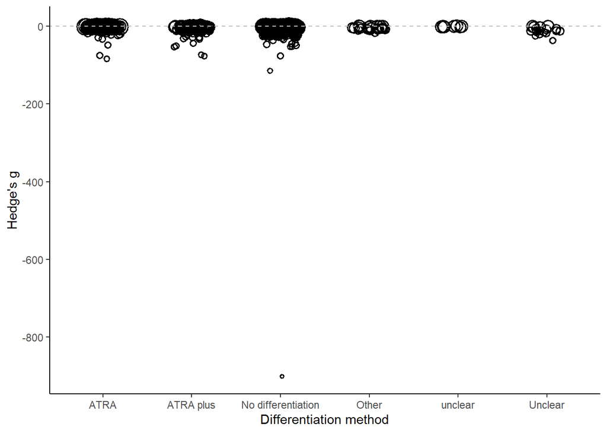

Diff. duration

```
##
## Multivariate Meta-Analysis Model (k = 237; method: REML)
##
## Variance Components:
##
##              estim    sqrt  nlvls  fixed                    factor
## sigma^2.1  23.2132  4.8180     62     no                rayyan.key
## sigma^2.2   3.6187  1.9023    237     no  rayyan.key/Comparison_ID
##
## Test for Residual Heterogeneity:
## QE(df = 225) = 1299.8106, p-val < .0001
##
## Test of Moderators (coefficients 2:12):
## QM(df = 11) = 19.7929, p-val = 0.0483
##
## Model Results:
##
##                                                     estimate      se     zval
## intrcpt                                              -7.8424  2.4113  -3.2523
## dados_meta_smd$Diferentiation_duration_days10.0      -4.1827  3.6715  -1.1392
## dados_meta_smd$Diferentiation_duration_days12.0       5.0532  5.8276   0.8671
## dados_meta_smd$Diferentiation_duration_days14.0       2.9320  4.2731   0.6862
## dados_meta_smd$Diferentiation_duration_days3.0       -0.0437  3.0803  -0.0142
## dados_meta_smd$Diferentiation_duration_days4.0        6.4112  3.2967   1.9447
## dados_meta_smd$Diferentiation_duration_days5.0       -0.6896  3.1944  -0.2159
## dados_meta_smd$Diferentiation_duration_days6.0        3.3771  2.7549   1.2259
## dados_meta_smd$Diferentiation_duration_days7.0        4.6439  2.7454   1.6915
## dados_meta_smd$Diferentiation_duration_days8.0        3.4484  3.0513   1.1302
## dados_meta_smd$Diferentiation_duration_days9.0        5.8111  5.5294   1.0509
## dados_meta_smd$Diferentiation_duration_daysUnclear    1.0967  3.3573   0.3267
##                                                       pval     ci.lb    ci.ub
## intrcpt                                             0.0011  -12.5685  -3.1163
## dados_meta_smd$Diferentiation_duration_days10.0     0.2546  -11.3787   3.0133
## dados_meta_smd$Diferentiation_duration_days12.0     0.3859   -6.3687  16.4752
## dados_meta_smd$Diferentiation_duration_days14.0     0.4926   -5.4431  11.3071
## dados_meta_smd$Diferentiation_duration_days3.0      0.9887   -6.0809   5.9935
## dados_meta_smd$Diferentiation_duration_days4.0      0.0518   -0.0503  12.8727
## dados_meta_smd$Diferentiation_duration_days5.0      0.8291   -6.9506   5.5713
## dados_meta_smd$Diferentiation_duration_days6.0      0.2203   -2.0224   8.7765
## dados_meta_smd$Diferentiation_duration_days7.0      0.0907   -0.7369  10.0248
## dados_meta_smd$Diferentiation_duration_days8.0      0.2584   -2.5319   9.4288
## dados_meta_smd$Diferentiation_duration_days9.0      0.2933   -5.0264  16.6486
## dados_meta_smd$Diferentiation_duration_daysUnclear  0.7439   -5.4834   7.6768
##
## intrcpt                                             **
## dados_meta_smd$Diferentiation_duration_days10.0
## dados_meta_smd$Diferentiation_duration_days12.0
## dados_meta_smd$Diferentiation_duration_days14.0
## dados_meta_smd$Diferentiation_duration_days3.0
## dados_meta_smd$Diferentiation_duration_days4.0       .
## dados_meta_smd$Diferentiation_duration_days5.0
## dados_meta_smd$Diferentiation_duration_days6.0
## dados_meta_smd$Diferentiation_duration_days7.0       .
## dados_meta_smd$Diferentiation_duration_days8.0
## dados_meta_smd$Diferentiation_duration_days9.0
## dados_meta_smd$Diferentiation_duration_daysUnclear
##
## ---
## Signif. codes:  0 '***' 0.001 '**' 0.01 '*' 0.05 '.' 0.1 ' ' 1
```

Diff. duration bubble plot

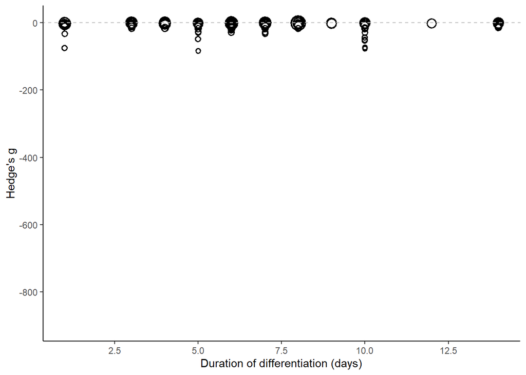

Aggregation

```
##
## Multivariate Meta-Analysis Model (k = 1198; method: REML)
##
## Variance Components:
##
##             estim    sqrt  nlvls  fixed                    factor
## sigma^2.1  7.4586  2.7310    359     no                rayyan.key
## sigma^2.2  5.2419  2.2895   1198     no  rayyan.key/Comparison_ID
##
## Test for Residual Heterogeneity:
## QE(df = 1194) = 6923.1126, p-val < .0001
##
## Test of Moderators (coefficients 2:4):
## QM(df = 3) = 18.6768, p-val = 0.0003
##
## Model Results:
##
##                                                                              estimate
## intrcpt                                                                       -5.6801
## relevel(factor(dados_meta_smd$Abeta_aggregation), ref = "Unclear")Fibers      -0.2812
## relevel(factor(dados_meta_smd$Abeta_aggregation), ref = "Unclear")Monomers     1.8739
## relevel(factor(dados_meta_smd$Abeta_aggregation), ref = "Unclear")Oligomers    0.9218
##                                                                                  se
## intrcpt                                                                      0.2501
## relevel(factor(dados_meta_smd$Abeta_aggregation), ref = "Unclear")Fibers     0.5167
## relevel(factor(dados_meta_smd$Abeta_aggregation), ref = "Unclear")Monomers   0.5819
## relevel(factor(dados_meta_smd$Abeta_aggregation), ref = "Unclear")Oligomers  0.3566
##                                                                                  zval
## intrcpt                                                                      -22.7069
## relevel(factor(dados_meta_smd$Abeta_aggregation), ref = "Unclear")Fibers      -0.5443
## relevel(factor(dados_meta_smd$Abeta_aggregation), ref = "Unclear")Monomers     3.2201
## relevel(factor(dados_meta_smd$Abeta_aggregation), ref = "Unclear")Oligomers    2.5845
##                                                                                pval
## intrcpt                                                                      <.0001
## relevel(factor(dados_meta_smd$Abeta_aggregation), ref = "Unclear")Fibers     0.5862
## relevel(factor(dados_meta_smd$Abeta_aggregation), ref = "Unclear")Monomers   0.0013
## relevel(factor(dados_meta_smd$Abeta_aggregation), ref = "Unclear")Oligomers  0.0098
##                                                                                ci.lb
## intrcpt                                                                      -6.1704
## relevel(factor(dados_meta_smd$Abeta_aggregation), ref = "Unclear")Fibers     -1.2939
## relevel(factor(dados_meta_smd$Abeta_aggregation), ref = "Unclear")Monomers    0.7333
## relevel(factor(dados_meta_smd$Abeta_aggregation), ref = "Unclear")Oligomers   0.2228
##                                                                                ci.ub
## intrcpt                                                                      -5.1898
## relevel(factor(dados_meta_smd$Abeta_aggregation), ref = "Unclear")Fibers      0.7314
## relevel(factor(dados_meta_smd$Abeta_aggregation), ref = "Unclear")Monomers    3.0144
## relevel(factor(dados_meta_smd$Abeta_aggregation), ref = "Unclear")Oligomers   1.6208
##
## intrcpt                                                                      ***
## relevel(factor(dados_meta_smd$Abeta_aggregation), ref = "Unclear")Fibers
## relevel(factor(dados_meta_smd$Abeta_aggregation), ref = "Unclear")Monomers    **
## relevel(factor(dados_meta_smd$Abeta_aggregation), ref = "Unclear")Oligomers   **
##
## ---
## Signif. codes:  0 '***' 0.001 '**' 0.01 '*' 0.05 '.' 0.1 ' ' 1
```

Aggregation bubble plot

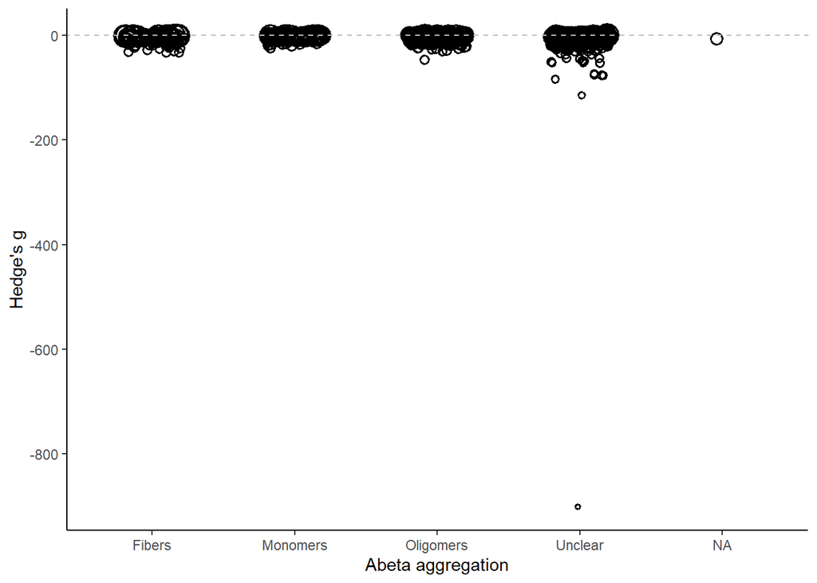

Abeta concentration

```
##
## Multivariate Meta-Analysis Model (k = 1181; method: REML)
##
## Variance Components:
##
##             estim    sqrt  nlvls  fixed                    factor
## sigma^2.1  7.0196  2.6494    352     no                rayyan.key
## sigma^2.2  5.5220  2.3499   1181     no  rayyan.key/Comparison_ID
##
## Test for Residual Heterogeneity:
## QE(df = 1179) = 7073.6479, p-val < .0001
##
## Test of Moderators (coefficient 2):
## QM(df = 1) = 17.6891, p-val < .0001
##
## Model Results:
##
##                                          estimate      se      zval    pval
## intrcpt                                   -5.0507  0.1907  -26.4801  <.0001
## dados_meta_smd_max2500$Concentration_uM   -0.0150  0.0036   -4.2058  <.0001
##                                            ci.lb    ci.ub
## intrcpt                                  -5.4245  -4.6769  ***
## dados_meta_smd_max2500$Concentration_uM  -0.0220  -0.0080  ***
##
## ---
## Signif. codes:  0 '***' 0.001 '**' 0.01 '*' 0.05 '.' 0.1 ' ' 1
```

Abeta concentration bubble plot

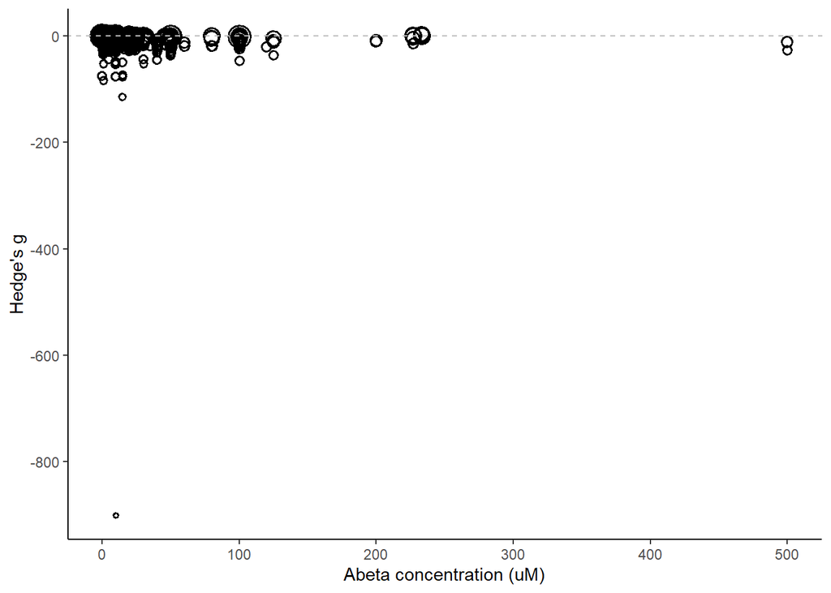

Abeta duration of exposure

```
##
## Multivariate Meta-Analysis Model (k = 1188; method: REML)
##
## Variance Components:
##
##             estim    sqrt  nlvls  fixed                    factor
## sigma^2.1  7.6266  2.7616    353     no                rayyan.key
## sigma^2.2  5.2529  2.2919   1188     no  rayyan.key/Comparison_ID
##
## Test for Residual Heterogeneity:
## QE(df = 1186) = 7119.4679, p-val < .0001
##
## Test of Moderators (coefficient 2):
## QM(df = 1) = 16.1797, p-val < .0001
##
## Model Results:
##
##                                            estimate      se      zval    pval
## intrcpt                                     -4.1984  0.3317  -12.6570  <.0001
## as.numeric(dados_meta_smd$Duration_hours)   -0.0339  0.0084   -4.0224  <.0001
##                                              ci.lb    ci.ub
## intrcpt                                    -4.8485  -3.5482  ***
## as.numeric(dados_meta_smd$Duration_hours)  -0.0504  -0.0174  ***
##
## ---
## Signif. codes:  0 '***' 0.001 '**' 0.01 '*' 0.05 '.' 0.1 ' ' 1
```

Abeta duration bubble plot

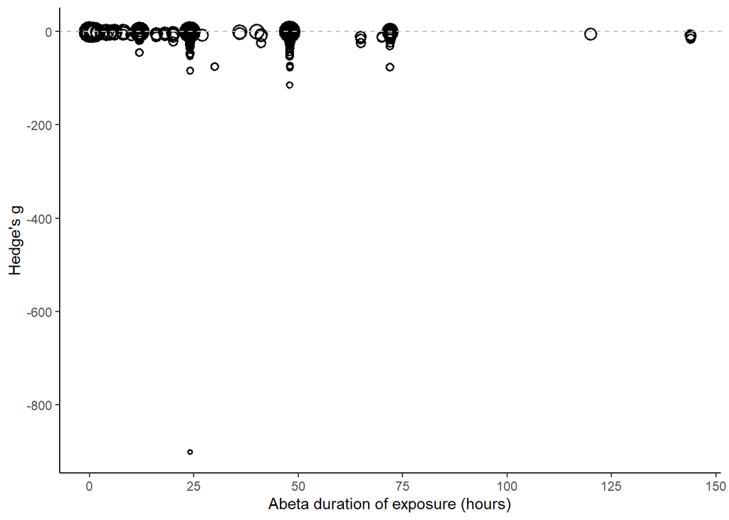

Assay

```
##
## Multivariate Meta-Analysis Model (k = 1192; method: REML)
##
## Variance Components:
##
##             estim    sqrt  nlvls  fixed                    factor
## sigma^2.1  7.4783  2.7346    358     no                rayyan.key
## sigma^2.2  5.5075  2.3468   1192     no  rayyan.key/Comparison_ID
##
## Test for Residual Heterogeneity:
## QE(df = 1186) = 7095.0321, p-val < .0001
##
## Test of Moderators (coefficients 2:6):
## QM(df = 5) = 2.5776, p-val = 0.7648
##
## Model Results:
##
##                                                          estimate      se
## intrcpt                                                   -5.4025  0.2060
## relevel(factor(dados_meta_smd$Assay), ref = "MTT")CCK-8   -0.0048  0.9684
## relevel(factor(dados_meta_smd$Assay), ref = "MTT")EZ4U    -0.2371  2.9840
## relevel(factor(dados_meta_smd$Assay), ref = "MTT")MTS      0.1711  0.9262
## relevel(factor(dados_meta_smd$Assay), ref = "MTT")WST      1.1639  0.7417
## relevel(factor(dados_meta_smd$Assay), ref = "MTT")XTT      0.5414  1.5561
##                                                              zval    pval
## intrcpt                                                  -26.2304  <.0001
## relevel(factor(dados_meta_smd$Assay), ref = "MTT")CCK-8   -0.0049  0.9961
## relevel(factor(dados_meta_smd$Assay), ref = "MTT")EZ4U    -0.0795  0.9367
## relevel(factor(dados_meta_smd$Assay), ref = "MTT")MTS      0.1848  0.8534
## relevel(factor(dados_meta_smd$Assay), ref = "MTT")WST      1.5692  0.1166
## relevel(factor(dados_meta_smd$Assay), ref = "MTT")XTT      0.3479  0.7279
##                                                            ci.lb    ci.ub
## intrcpt                                                  -5.8061  -4.9988  ***
## relevel(factor(dados_meta_smd$Assay), ref = "MTT")CCK-8  -1.9028   1.8933
## relevel(factor(dados_meta_smd$Assay), ref = "MTT")EZ4U   -6.0857   5.6114
## relevel(factor(dados_meta_smd$Assay), ref = "MTT")MTS    -1.6442   1.9865
## relevel(factor(dados_meta_smd$Assay), ref = "MTT")WST    -0.2898   2.6175
## relevel(factor(dados_meta_smd$Assay), ref = "MTT")XTT    -2.5084   3.5913
##
## ---
## Signif. codes:  0 '***' 0.001 '**' 0.01 '*' 0.05 '.' 0.1 ' ' 1
```

Assay bubble plot

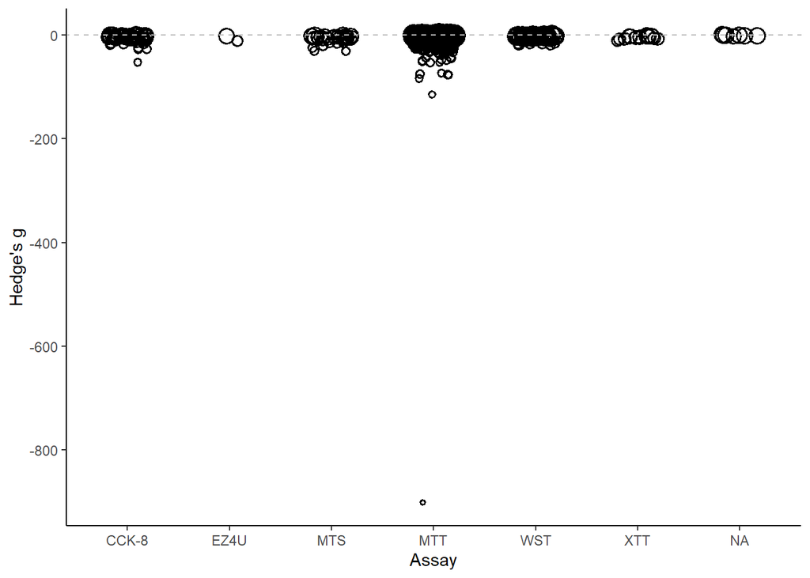

Cell density

```
##
## Multivariate Meta-Analysis Model (k = 694; method: REML)
##
## Variance Components:
##
##             estim    sqrt  nlvls  fixed                    factor
## sigma^2.1  8.2272  2.8683    211     no                rayyan.key
## sigma^2.2  5.8980  2.4286    694     no  rayyan.key/Comparison_ID
##
## Test for Residual Heterogeneity:
## QE(df = 692) = 4104.3383, p-val < .0001
##
## Test of Moderators (coefficient 2):
## QM(df = 1) = 0.0027, p-val = 0.9588
##
## Model Results:
##
##                                          estimate      se      zval    pval
## intrcpt                                   -5.5833  0.2611  -21.3867  <.0001
## as.numeric(dados_meta_smd$Cell_density)    0.0000  0.0000    0.0517  0.9588
##                                            ci.lb    ci.ub
## intrcpt                                  -6.0950  -5.0716  ***
## as.numeric(dados_meta_smd$Cell_density)  -0.0000   0.0000
##
## ---
## Signif. codes:  0 '***' 0.001 '**' 0.01 '*' 0.05 '.' 0.1 ' ' 1
```

Cell density bubble plot

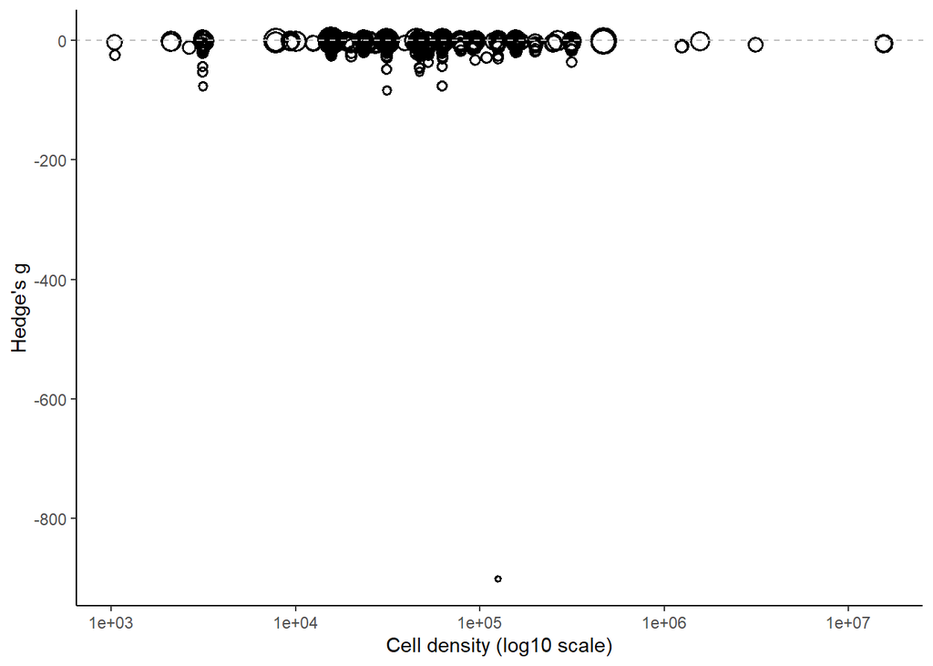

# Multivariate Meta-regressions (3-level)

“All combinations of variables from the selected list were tested in multivariable models, and the best models were ranked by corrected Akaike Information Criteria (AICc). For each best model selected (for complete, training and reactivation datasets with 2- and 3-level analyses), we decomposed the R2 value for each moderator included. For this, we calculated the mean of the differences between R2 from models with and without the moderator in all possible orders of moderator inclusion. Additionally, we performed a Q test of moderators for each variable (including all dummy variables for each categorical moderator) to obtain p-values for individual variables.”

Functions to decompose R2 (3-level)

Como a gente só pode usar as comparacoes que tenham a descricao completa de todas as variáveis testadas, precisamos filtrar os dadose conferir se seguimos com N suficiente.

Considering all pre-registered variables, we’d have 99 experiments available (i.e. 1100 exclusions due to missing data). As we have 7 variables, we should have at least 70 comparisons - so can use all of them now. There are 128 possible models.

```
## Initialization...
## TASK: Exhaustive screening of candidate set.
## Fitting...
##
## After 50 models:
## Best model: yi~1+Diferentiation_duration_days+Concentration_uM
## Crit= 589.848133386275
## Mean crit= 611.101638609329
##
## After 100 models:
## Best model: yi~1+Diferentiation_duration_days+Concentration_uM+Duration_hours
## Crit= 586.616231016249
## Mean crit= 609.767956837361
##
## After 150 models:
## Best model: yi~1+Diferentiation_duration_days+Concentration_uM+Duration_hours
## Crit= 586.616231016249
## Mean crit= 609.017884044364
## Completed.
```

```
## glmulti.analysis
## Method: h / Fitting: rma.mv.glmulti / IC used: aicc
## Level: 1 / Marginality: FALSE
## From 128 models:
## Best IC: 586.616231016249
## Best model:
## [1] "yi ~ 1 + Diferentiation_duration_days + Concentration_uM + Duration_hours"
## Evidence weight: 0.31797522856754
## Worst IC: 631.18949715955
## 2 models within 2 IC units.
## 12 models to reach 95% of evidence weight.
```

Decomposing R2 for the best model:

```
## [1] "Running models for Diferentiation_duration_days"
## [1] "Running models for Concentration_uM"
## [1] "Running models for Duration_hours"
## [1] "Running models for Cell_density"
```

### excluindo outliers de concentracao de abeta:

Como a gente só pode usar as comparacoes que tenham a descricao completa de todas as variáveis testadas, precisamos filtrar os dadose conferir se seguimos com N suficiente.

Considering all pre-registered variables, we’d have 99 experiments available (i.e. 1082 exclusions due to missing data). As we have 7 variables, we should have at least 70 comparisons - so can use all of them now. There are 128 possible models.

# Controle de qualidade dos dados

Revisor como moderador

```
##
##                       Created.By   n
## 1              Adriano Sebollela  37
## 2              Ana Paula Sampaio  77
## 3                  Antônio Felix 133
## 4  Clarissa Franca Dias Carneiro  43
## 5              Giovanna Nogueira 142
## 6   Giulia Scarcella Cancelliero 140
## 7          Glaucia Maria Almeida 136
## 8             Nathalia Fernandes 122
## 9              Nathalia Pinheiro 217
## 10              Samantha Martins 152
```

```
##
## Multivariate Meta-Analysis Model (k = 1199; method: REML)
##
## Variance Components:
##
##             estim    sqrt  nlvls  fixed                    factor
## sigma^2.1  7.5533  2.7483    359     no                rayyan.key
## sigma^2.2  5.4008  2.3240   1199     no  rayyan.key/Comparison_ID
##
## Test for Residual Heterogeneity:
## QE(df = 1189) = 6963.8167, p-val < .0001
##
## Test of Moderators (coefficients 2:10):
## QM(df = 9) = 12.3658, p-val = 0.1935
##
## Model Results:
##
##                                                                                                     estimate
## intrcpt                                                                                              -5.8458
## relevel(factor(dados_meta_smd$Created.By), ref = "Adriano Sebollela")Ana Paula Sampaio                1.9722
## relevel(factor(dados_meta_smd$Created.By), ref = "Adriano Sebollela")Antônio Felix                    0.6644
## relevel(factor(dados_meta_smd$Created.By), ref = "Adriano Sebollela")Clarissa Franca Dias Carneiro    0.2427
## relevel(factor(dados_meta_smd$Created.By), ref = "Adriano Sebollela")Giovanna Nogueira                0.4489
## relevel(factor(dados_meta_smd$Created.By), ref = "Adriano Sebollela")Giulia Scarcella Cancelliero    -0.0727
## relevel(factor(dados_meta_smd$Created.By), ref = "Adriano Sebollela")Glaucia Maria Almeida            1.0564
## relevel(factor(dados_meta_smd$Created.By), ref = "Adriano Sebollela")Nathalia Fernandes               0.7342
## relevel(factor(dados_meta_smd$Created.By), ref = "Adriano Sebollela")Nathalia Pinheiro                1.0432
## relevel(factor(dados_meta_smd$Created.By), ref = "Adriano Sebollela")Samantha Martins                -0.5121
##                                                                                                         se
## intrcpt                                                                                             0.9009
## relevel(factor(dados_meta_smd$Created.By), ref = "Adriano Sebollela")Ana Paula Sampaio              1.1177
## relevel(factor(dados_meta_smd$Created.By), ref = "Adriano Sebollela")Antônio Felix                  1.0265
## relevel(factor(dados_meta_smd$Created.By), ref = "Adriano Sebollela")Clarissa Franca Dias Carneiro  1.2237
## relevel(factor(dados_meta_smd$Created.By), ref = "Adriano Sebollela")Giovanna Nogueira              1.0637
## relevel(factor(dados_meta_smd$Created.By), ref = "Adriano Sebollela")Giulia Scarcella Cancelliero   1.0501
## relevel(factor(dados_meta_smd$Created.By), ref = "Adriano Sebollela")Glaucia Maria Almeida          1.0501
## relevel(factor(dados_meta_smd$Created.By), ref = "Adriano Sebollela")Nathalia Fernandes             1.1071
## relevel(factor(dados_meta_smd$Created.By), ref = "Adriano Sebollela")Nathalia Pinheiro              1.0479
## relevel(factor(dados_meta_smd$Created.By), ref = "Adriano Sebollela")Samantha Martins               1.0459
##                                                                                                        zval
```

[output cut: 42 more lines]

```
## relevel(factor(dados_meta_smd$Created.By), ref = "Adriano Sebollela")Samantha Martins                1.5378
##
## intrcpt                                                                                             ***
## relevel(factor(dados_meta_smd$Created.By), ref = "Adriano Sebollela")Ana Paula Sampaio                .
## relevel(factor(dados_meta_smd$Created.By), ref = "Adriano Sebollela")Antônio Felix
## relevel(factor(dados_meta_smd$Created.By), ref = "Adriano Sebollela")Clarissa Franca Dias Carneiro
## relevel(factor(dados_meta_smd$Created.By), ref = "Adriano Sebollela")Giovanna Nogueira
## relevel(factor(dados_meta_smd$Created.By), ref = "Adriano Sebollela")Giulia Scarcella Cancelliero
## relevel(factor(dados_meta_smd$Created.By), ref = "Adriano Sebollela")Glaucia Maria Almeida
## relevel(factor(dados_meta_smd$Created.By), ref = "Adriano Sebollela")Nathalia Fernandes
## relevel(factor(dados_meta_smd$Created.By), ref = "Adriano Sebollela")Nathalia Pinheiro
## relevel(factor(dados_meta_smd$Created.By), ref = "Adriano Sebollela")Samantha Martins
##
## ---
## Signif. codes:  0 '***' 0.001 '**' 0.01 '*' 0.05 '.' 0.1 ' ' 1
```

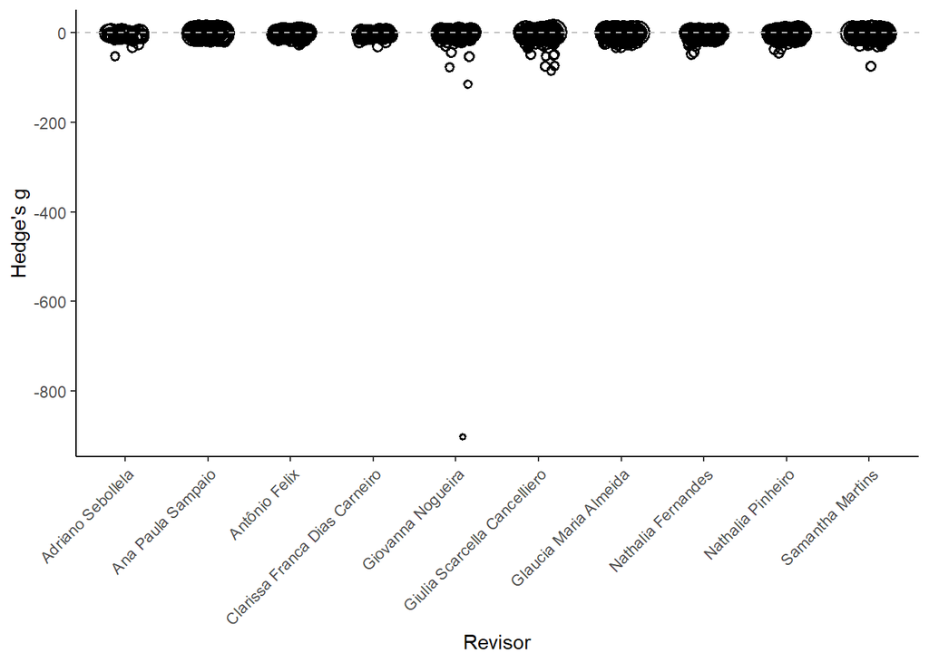

# Análises descritivas

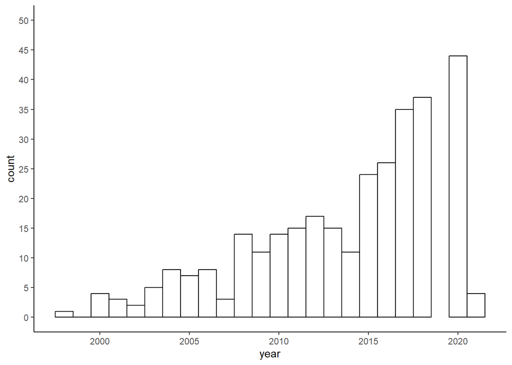

Article-level info:

| Feature | Count | Percent |
| --- | --- | --- |
| Studies testing reversal | 250 | 69.6 |
| Provides sample size calculation | 0 | 0.0 |
| Includes conflict of interest statement | 182 | 50.7 |
| Has pre-registered | 11 | 3.1 |

Experiment-level info

Assay

| Assay | n |
| --- | --- |
| MTT | 1011 |
| WST | 81 |
| CCK-8 | 51 |
| MTS | 32 |
| XTT | 15 |
| NA | 7 |
| EZ4U | 2 |

Cell line

| Cell_source | n |
| --- | --- |
| Cell bank | 646 |
| Unclear | 471 |
| Donation | 82 |

| Cell_bank | n |
| --- | --- |
| American Type Culture Collection (ATCC) | 302 |
| European Collection of Authenticated Cell Cultures (ECACC) | 192 |
| Chinese Academy of Sciences | 44 |
| Leibniz Institute DSMZ - German Collection of Microorganisms and Cell Cultures GmbH | 29 |
| Riken Cell Bank | 28 |
| National Centre for Cell Science (NCCS) | 15 |
| Sigma-Aldrich | 8 |
| Institute of Biochemistry and Cell Biology | 7 |
| Invitrogen | 5 |
| Pasteur Institute of Iran | 5 |
| Korean Cell Line Bank | 4 |
| NA | 3 |
| cells were purchased from Zhong Qiao Xin Zhou Biotec Co., Ltd (Shanghai, China) | 2 |
| LGC Promo-chem | 1 |
| The Cell Resource Centre of Institute of Basic Medicine | 1 |

| Cell_authentication | n |
| --- | --- |
| No | 1176 |
| Yes, no protocol | 17 |
| NA | 6 |

| Cell_mycoplasma | n |
| --- | --- |
| No | 1175 |
| Yes, no protocol | 18 |
| NA | 6 |

| Serum_type | n |
| --- | --- |
| FBS | 773 |
| FCS | 233 |
| Unclear | 184 |
| FBS and HS | 3 |
| CS | 2 |
| NO SERUM | 2 |
| FCS and FHS | 1 |
| FCS and HS | 1 |

| Serum_concentration | n |
| --- | --- |
| 0.1 | 765 |
| 0.15 | 205 |
| NA | 192 |
| 0.05 | 7 |
| 0.18 | 7 |
| 0.17 | 6 |
| 0.2 | 5 |
| 0.02 | 4 |
| 5% of each | 3 |
| 5% or 10 % | 2 |
| 0.12 | 1 |
| 10% and 5% | 1 |
| 5% and 10% | 1 |

Treatment

| Control_description | n |
| --- | --- |
| Unclear | 524 |
| Vehicle | 345 |
| Medium only | 289 |
| Other | 41 |

| Abeta_sequence | n |
| --- | --- |
| 1-42 | 961 |
| 1-40 | 218 |
| 1-43 | 10 |
| NA | 8 |
| 1-38 | 2 |

| Abeta_origin | n |
| --- | --- |
| Unclear | 625 |
| synthetic | 522 |
| recombinant | 52 |

| Abeta_species | n |
| --- | --- |
| Unclear | 964 |
| Human | 230 |
| Rat | 5 |

| Abeta_aggregation | n |
| --- | --- |
| Unclear | 539 |
| Oligomers | 463 |
| Fibers | 105 |
| Monomers | 91 |
| NA | 1 |

| Single_exposure | n |
| --- | --- |
| Yes, single | 1197 |
| Unclear | 1 |
| NA | 1 |

```
## # A tibble: 1 x 1
##   `mean(Duration_hours, na.rm = T)`
##                               <dbl>
## 1                              33.1
```

```
## # A tibble: 1 x 1
##   `sd(Duration_hours, na.rm = T)`
##                             <dbl>
## 1                            16.8
```

```
## # A tibble: 1 x 1
##   `median(Duration_hours, na.rm = T)`
##                                 <dbl>
## 1                                  24
```

```
## # A tibble: 1 x 1
##   `min(Duration_hours, na.rm = T)`
##                              <dbl>
## 1                                0
```

```
## # A tibble: 1 x 1
##   `max(Duration_hours, na.rm = T)`
##                              <dbl>
## 1                              144
```

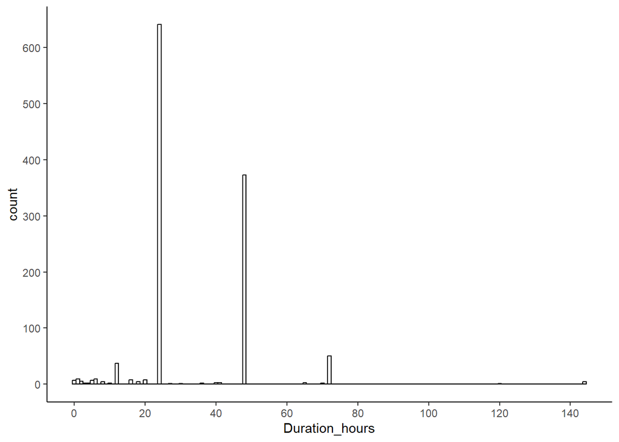

```
## # A tibble: 1 x 1
##   `mean(Concentration_uM, na.rm = T)`
##                                 <dbl>
## 1                                41.3
```

```
## # A tibble: 1 x 1
##   `sd(Concentration_uM, na.rm = T)`
##                               <dbl>
## 1                              873.
```

```
## # A tibble: 1 x 1
##   `median(Concentration_uM, na.rm = T)`
##                                   <dbl>
## 1                                     8
```

```
## # A tibble: 1 x 1
##   `min(Concentration_uM, na.rm = T)`
##                                <dbl>
## 1                                  0
```

```
## # A tibble: 1 x 1
##   `max(Concentration_uM, na.rm = T)`
##                                <dbl>
## 1                              30000
```

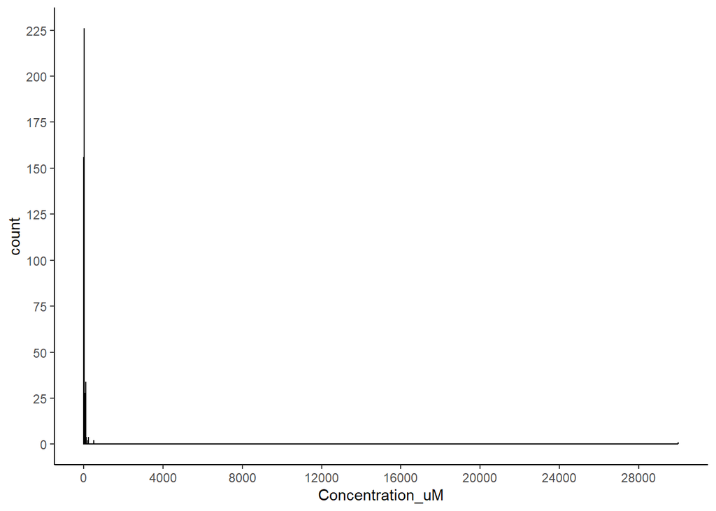

Diferenciacao

| Diferentiation_method | n |
| --- | --- |
| No differentiation | 928 |
| ATRA | 141 |
| ATRA plus | 79 |
| Other | 25 |
| Unclear | 19 |
| unclear | 7 |

Reporting

[output not shown]